# Investigating Fordgobike trips

## by Hammam Al-Alfi

## Investigation Overview

This slides investigate the duration of the individual rides made in a bike-sharing system covering the greater San Francisco Bay area on 2018.

## Dataset Overview

The dataset contains informations about individual rides made in a bike-sharing system covering the greater San Francisco Bay area on 2018.  
The informations includes:

- The starting and ending station of the trip and thier coordinates.
- The duration of the trip .
- The date and time of the start and end of the trip.
- The user type (Customer or Subsecriber).
- If the member is enrolled in Bike Share For All program (Yes or No).
- A derived-distance-column that gives the shortest distance on the surface of an ellipsoidal model of the earth between the start and end station.

## The distribution of the trips duration

I am going to start my presentantion by showing the distribution of the trips that has done on 2018.

- The subplot on the left showing the distibution of the duration using logarithmic scale for the duration as minutes,linear scale for the frequency and a vertical line showing the mean of the duration of all trips over 2018.From this subplot we see that there are no trips with durations less than one minute and the majority of distribution falls under short durations.
- The subplot on the right showing the distibution of the duration using logarithmic scale for the frequency and linear scale for the duration as hours.From this subplot we see that we have got no duration longer than 24 hours.

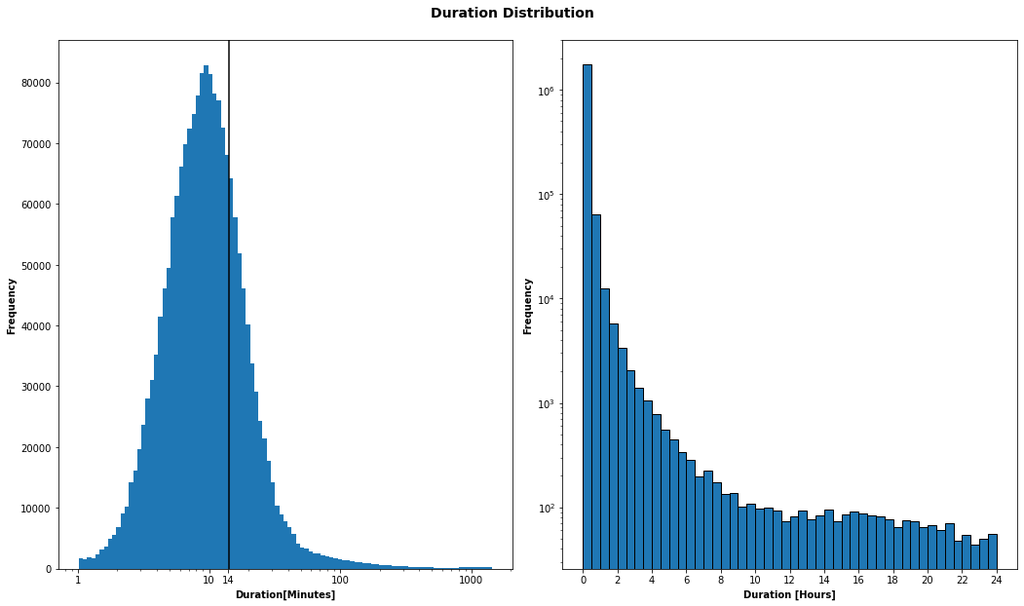

```python
fig,ax=plt.subplots(1,2,figsize=[14.70, 8.27])
plt.sca(ax[0])
#set current axes to ax[0] and plotting >>
# getting log base 10 of the duration as minutes to use to for getting a log bins.
duration_log=np.log10(df.duration/np.timedelta64(1,'m'))
#plotting a histogram of the duration as minutes with 100 bins that are log scaled
plt.hist((df.duration/np.timedelta64(1,'m')),bins=10**np.linspace(duration_log.min(),duration_log.max(),100))
plt.xscale('log') # using log scale for the x axis
plt.xlabel('Duration[minutes]'.title(),
               fontsize = 10, weight = "bold")# labeling x axis
plt.xticks([1,10,14,100,1000],[1,10,14,100,1000])# setting xticks
plt.axvline((df.duration/np.timedelta64(1,'m')).mean(),color='black')# plotting a vertical line of the mean of  the duration
plt.ylabel('Frequency'.title(),
               fontsize = 10, weight = "bold") #labeling the y axis

plt.sca(ax[1])
#set current axes to ax[1] and plotting >>
#plot a histogram of duration as hour with bin range from 0 to 24 hours with bin size of 0.5 hour
# and using log scale for the y axis.
plt.hist(df.duration/np.timedelta64(1,'h'),bins=np.arange(0,24+0.5,0.5),edgecolor='black',log=True)
plt.xticks(np.arange(0,24+1,2),labels=np.arange(0,24+1,2))
plt.xlabel('Duration [hours]'.title(),
               fontsize = 10, weight = "bold")
plt.ylabel('Frequency'.title(),
               fontsize = 10, weight = "bold")
fig.suptitle('Duration distribution'.title(),
               fontsize = 14, weight = "bold",y=1.04)
plt.tight_layout();
```

## The distribution of the distancs between the start and end stations.

The two subplots below showing the distribution of the distances as follows:

- the one on the left showing the distribution using square root scale for the distances that there is a spike on the distribution around the zero and this is because there is an amount of trips that started and ended at the same station so they have a distance of zero and because some stations are in quite close proximity. Further more, there is a gap between the spike and the rest of the distribution, this is because there is a few amount of stations with close proximity and then there is a gap in the distances between the stations.The rest of the distribution gose some how normally distibuted.
- The one on right has used logarithmic scale for the frequency and square root scale for the distances.From this plot we can see the outliers with one trip with a distance between 36 and 49 miles.

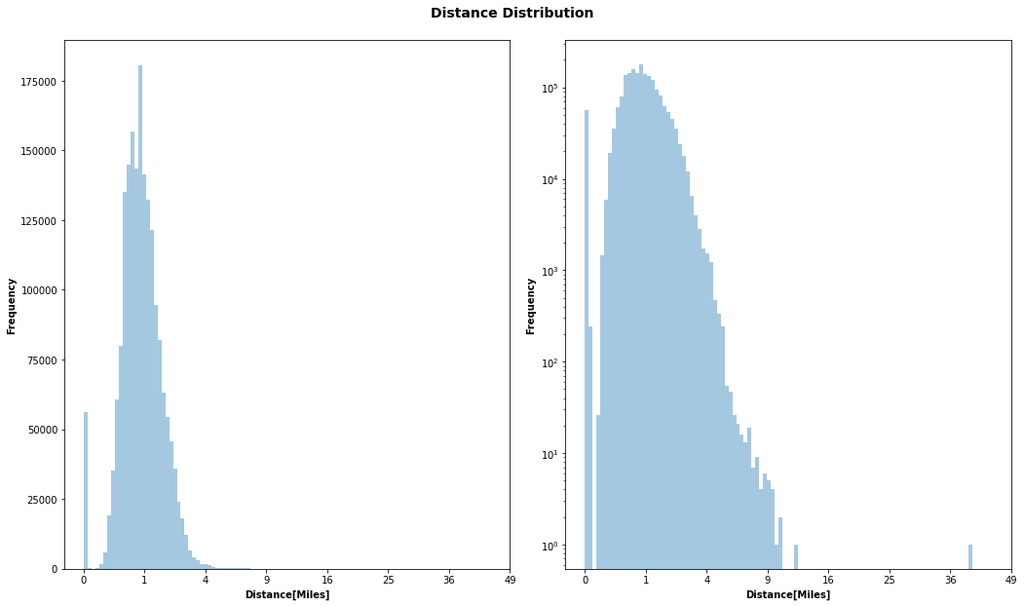

```python
fig,ax=plt.subplots(1,2,figsize=[14.70, 8.27])
distance_sqrt = np.sqrt(df.distance)

# plotting histogram on the third axes of  the square root values of the distance with 100 bins and setting the xticks and their labels  to show the real values of the distance

sns.distplot(distance_sqrt,kde=False,bins=100,ax=ax[0])
ax[0].set_xticks(np.arange(0,7+1,1))
ax[0].set_xticklabels(np.arange(0,7+1,1)**2)
ax[0].set_ylabel('Frequency'.title(),
               fontsize = 10, weight = "bold")
ax[0].set_xlabel('Distance[miles]'.title(),
               fontsize = 10, weight = "bold")
# plotting histogram on the forth axes of the square root values of the distance the distance and log scale for the y axis.
sns.distplot(distance_sqrt,kde=False,bins=100,ax=ax[1]);
ax[1].set_xticks(np.arange(0,7+1,1))
ax[1].set_xticklabels(np.arange(0,7+1,1)**2)
ax[1].set_ylabel('Frequency'.title(),
               fontsize = 10, weight = "bold")
ax[1].set_xlabel('Distance[miles]'.title(),
               fontsize = 10, weight = "bold")
ax[1].set_yscale('log')
fig.suptitle('Distance distribution'.title(),
               fontsize = 14, weight = "bold",y=1.04)
plt.tight_layout();
```

## Trips over weekdays

This plot showing the count of trips on weekdays bases on 2018

- Saturday and Sunday are the days with the lowest trips on 2018,Saturday and Sunday are the weekend so it seems that the there are less trips in the weekends .

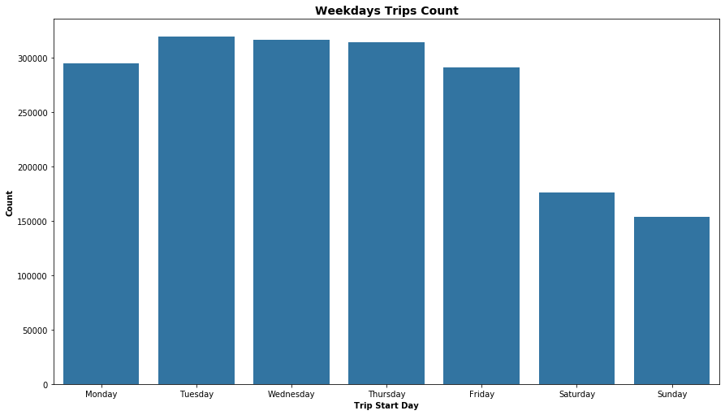

```python
# plotting a count plot of start day of the trip and using order argument to show the days in order of the starting day of the week to the weekend.
ordered_days = ['Monday','Tuesday','Wednesday','Thursday','Friday','Saturday','Sunday']
plt.figure(figsize = [14.70, 8.27])
sns.countplot(df.start_time.dt.day_name(),order=ordered_days,color=sns.color_palette()[0])
plt.xlabel('Trip Start Day'.title(),
               fontsize = 10, weight = "bold")
plt.ylabel('count'.title(),
               fontsize = 10, weight = "bold")
plt.title('Weekdays trips count'.title(),
               fontsize = 14, weight = "bold");
```

## Trips over day hours

The next plot shows the the count of trips on day-hours bases on 2018

- We see that the hours that has got the most trips count are 8:00 AM and 5:00 PM , maybe this because these are the rush hours , at 8:00 AM you go to work and at 5:00 PM you go to home. Just guessing :)
- The smallest amount of trips took a place late at night or after the midnight.

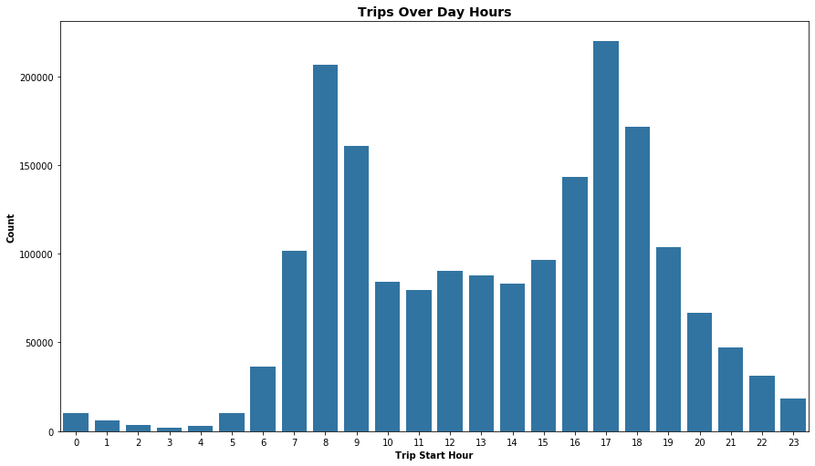

```python
#two subplots one for the count of the start time of trips per day hours and the other one for the start time
plt.figure(figsize = [14.70, 8.27])
sns.countplot(df.start_time.dt.hour,color=sns.color_palette()[0])
plt.ylabel('count'.title(),
               fontsize = 10, weight = "bold")
plt.xlabel('Trip start hour'.title(),
               fontsize = 10, weight = "bold")
plt.title('Trips over day hours'.title(),
               fontsize = 14, weight = "bold");
```

## User type and Bike Share For All programe percentages .

The two subplots below show the percentages of the trips that done on 2018 with respect to the user type if it's a Customer or a Subsecriber and the percentages and with respect to if the member is enrolled in Bike Share For All programe or not percentages.

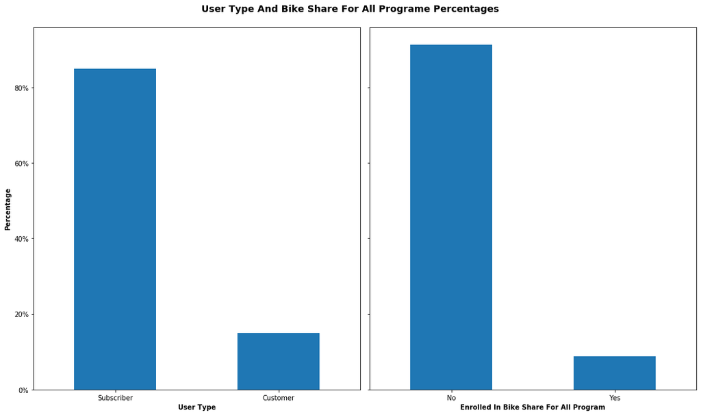

```python
fig,ax=plt.subplots(1,2,figsize=[14.70, 8.27],sharey='row')
# the first subplot is a bar plot of the normaized value counts of each user type which shows the percentages.
df.user_type.value_counts(normalize=True).plot.bar(ax=ax[0])
# the first subplot is a bar plot of the normaized value counts of each value in bike_share_for_all_trip which shows the percentages.
df.bike_share_for_all_trip.value_counts(normalize=True).plot.bar(ax=ax[1])
#polishing the plots
ax[0].set_xlabel('User Type'.title(),
               fontsize = 10, weight = "bold")
ax[0].tick_params(labelrotation=0)
ax[1].set_xlabel('Enrolled in Bike Share For All program'.title(),
               fontsize = 10, weight = "bold")
ax[1].tick_params(labelrotation=0)
ax[0].set_ylabel('Percentage'.title(),
               fontsize = 10, weight = "bold")
ax[0].set_yticklabels(['0%','20%','40%','60%','80%'])
fig.suptitle('User type and Bike Share For All programe percentages'.title(),
               fontsize = 14, weight = "bold",y=1.04);
plt.tight_layout();
```

## Distance Vs Duration.

This plot is a heat map of the distance as miles on square root scale on the y axis and the duration as minutes on log scale on the x axis and the color bar showing the count of the trips for each area.

- This plot shows the gap in the distance distribution
- look how the majority (purple area) of the trips follow a positive relation for short durations (above the gap) on a log-square scale.
- For quite short and zero distances (under the gap) the trips durations are of wide range from 1 minute to over 1000 minutes.
- For large (longer than the purple area) the distance tends to fall between a specific range except some outliers like the one between 36 and 49 miles.

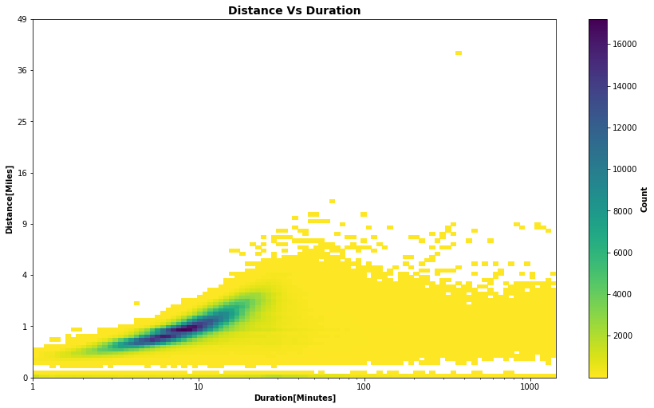

```python
df['duration_hours']=df.duration/np.timedelta64(1,'h') # getting a colum of duration as hours
df['duration_minutes']=df.duration/np.timedelta64(1,'m') # getting a colum of duration as minutes
#getting the x axis bins for the heat map as 100 log scaled bins started from the minimum value to the maximum value of the duration
x_bins=10**np.linspace(np.log10(df.duration_minutes).min(),np.log10(df.duration_minutes).max(),100)
#getting the y axis bins for the heat map as 100 square root scaled bins started from the minimum value to the maximum value of the distance
y_bins = np.linspace(distance_sqrt.min(),distance_sqrt.max(),100)

plt.figure(figsize=[14.70, 8.27])
#plotting the heat map using the duration as minutes and the square root of the distance and setting the bins .
plt.hist2d(x=df.duration_minutes,y=distance_sqrt, cmap = 'viridis_r',bins=[x_bins,y_bins],cmin=1)
plt.xscale('log')
plt.yticks([0,1,2,3,4,5,6,7],[0,1,4,9,16,25,36,49])
plt.xticks([1,10,100,1000],[1,10,100,1000])
plt.colorbar().set_label('Count'.title(),
               fontsize = 10, weight = "bold")
plt.xlabel('Duration[minutes]'.title(),
               fontsize = 10, weight = "bold")
plt.ylabel('Distance[miles]'.title(),
               fontsize = 10, weight = "bold")
plt.title('Distance Vs Duration'.title(),
               fontsize = 14, weight = "bold");
```

## Duration mean Vs Weekdays

This plot shows bar plot of the means of the trips duration took a place in each week day on 2018 with error bars showing the uncertainty of the mean .

- Something interesting here, look how Saturaday and Sunday which are the days with the lowest trips count are the days with trips that are on average with longer durations than the other days. This maybe becuase the members that do trips in these day are doing it for fun cause it's a weekend so they tend to spend more time cause they are not on rush to get to thier works.

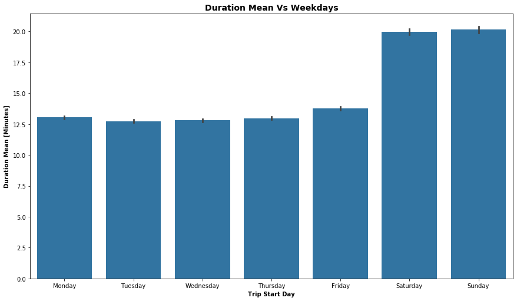

```python
# plotting barplot of the mean of duration as minutes and start time as weekdays

plt.figure(figsize=(14.70,8.27))
sns.barplot(x=df.start_time.dt.day_name(),y=df.duration_minutes,order=ordered_days,color=sns.color_palette()[0])
plt.xlabel('Trip Start Day'.title(),
               fontsize = 10, weight = "bold")
plt.ylabel('Duration Mean [minutes]'.title(),
               fontsize = 10, weight = "bold")
plt.title('Duration mean Vs Weekdays'.title(),
               fontsize = 14, weight = "bold");
```

## Duration mean Vs day hours

This plot shows bar plot of the means of the trips duration took a place in each day hour on 2018 with error bars showing the uncertainty of the mean .

- Another ineresting stuff going on here .For the hours 12:00,01:00 ,02:00,03:00 and 4:00 AM that have the lowest tips count they are the hours with trips on average of longer durations than the rest of the day . I think if your trip gonna take a long time why you don't start it early, like at 03:00 AM :).

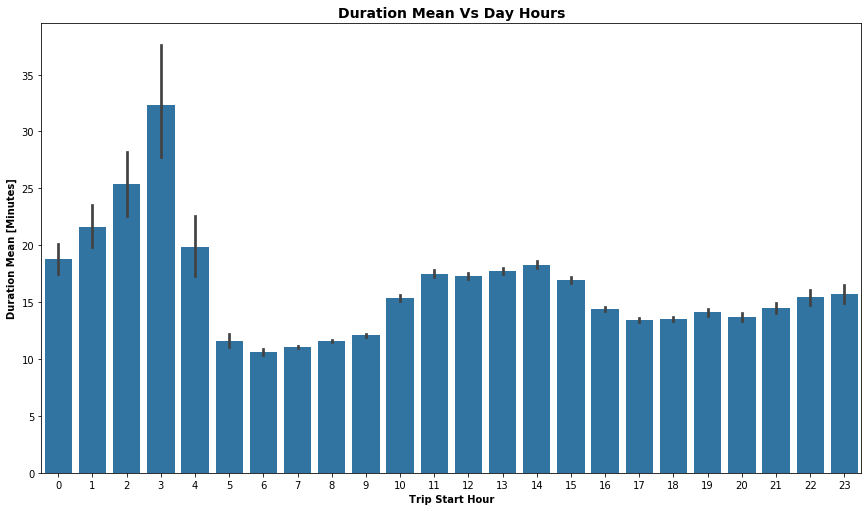

```python
# plotting barplot of the mean of duration as minutes and start time as day  hours
plt.figure(figsize=(14.70,8.27))
sns.barplot(x=df.start_time.dt.hour,y=df.duration_minutes,color=sns.color_palette()[0])
plt.xlabel('Trip Start Hour'.title(),
               fontsize = 10, weight = "bold")
plt.ylabel('Duration Mean [minutes]'.title(),
               fontsize = 10, weight = "bold")
plt.title('Duration mean Vs day hours'.title(),
               fontsize = 14, weight = "bold");
```

## User Type Vs Duration

This is a plot showing the percentages of each user type on a log scaled bins of the durations.

- The plot showing that the longer the duration of the trip the more likely to be done by a Customer .

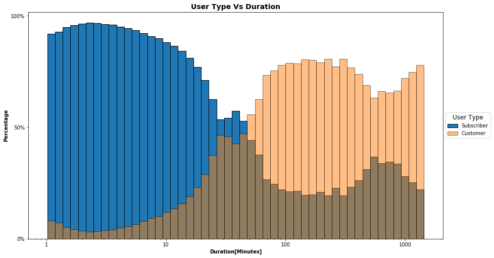

```python
plt.figure(figsize=(14.70,8.27))
# getting a log scaled bins of the duration as minutes
bin_edges = 10**np.linspace(np.log10(df.duration_minutes).min(),np.log10(df.duration_minutes).max(),50)
# getting the number of points in each bin
bin_idxs = pd.cut(df.duration_minutes,bin_edges,include_lowest =True,right=True,labels=False).astype(int)
pts_per_bin = df.groupby(bin_idxs).size()
#plotting a weighted histogram of the duration as minutes and Subscriber user type
plt.hist(df.duration_minutes,
         bins = bin_edges,
         weights = (df.user_type=='Subscriber')/pts_per_bin[bin_idxs].values,
         edgecolor='black',
         label='Subscriber')
#plotting a weighted histogram of the duration as minutes and Customer user type
plt.hist(df.duration_minutes,
         bins = bin_edges,
         weights = (df.user_type=='Customer')/pts_per_bin[bin_idxs].values,
         edgecolor='black',
         label='Customer',
        alpha=0.5)
#polishing the plot by setting the title of the legend,relabeling the ticks and setting the labels.
plt.legend(title='User Type',loc='center left', bbox_to_anchor=(1, 0.5),
            title_fontsize = 12)
plt.xscale('log')
plt.xticks([1,10,100,1000],[1,10,100,1000])
plt.yticks([0,0.5,1],['0%','50%','100%'])
plt.xlabel('Duration[minutes]'.title(),
               fontsize = 10, weight = "bold")
plt.ylabel('Percentage'.title(),
               fontsize = 10, weight = "bold")
plt.title('User type Vs Duration'.title(),
               fontsize = 14, weight = "bold");
```

- The plot showing that the Customers tend to do longer distances and the Subsecribers tends to do short ones.
- The Outrageous trip of distance between 36 and 49 miles is done by a customer and there's another outlier over 9 miles done by a Customer too .

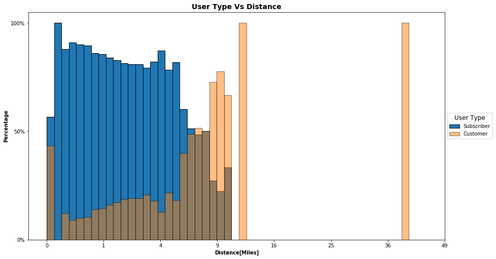

```python
plt.figure(figsize=(14.70,8.27))
# getting bins of the square root of the distance

bin_edges = np.linspace(np.sqrt(df.distance).min(),np.sqrt(df.distance).max(),50)
# getting the number of points in each bin

bin_idxs = pd.cut(np.sqrt(df.distance),bin_edges,include_lowest =True,right=True,labels=False).astype(int)
pts_per_bin = df.groupby(bin_idxs).size()
#plotting a weighted histogram of the square root of the distance and Subscriber user type

plt.hist(np.sqrt(df.distance),
         bins = bin_edges,
         weights = (df.user_type=='Subscriber')/pts_per_bin[bin_idxs].values,
         edgecolor='black',
         label='Subscriber')
#plotting a weighted histogram of the square root of the distance and Customer user type

plt.hist(np.sqrt(df.distance), bins = bin_edges,
         weights = (df.user_type=='Customer')/pts_per_bin[bin_idxs].values,
         edgecolor='black',
         alpha=0.5,
         label='Customer')

plt.legend(title='User Type',loc='center left', bbox_to_anchor=(1, 0.5),
           title_fontsize = 12)
plt.xticks([0,1,2,3,4,5,6,7],[0,1,4,9,16,25,36,49]);
plt.yticks([0,0.5,1],['0%','50%','100%'])
plt.xlabel('Distance[miles]'.title(),
               fontsize = 10, weight = "bold")
plt.ylabel('Percentage'.title(),
               fontsize = 10, weight = "bold")
plt.title('User type Vs Distance'.title(),
               fontsize = 14, weight = "bold");
```

## User type , Bike Share For All program and Duration.

This last plot is a heat map comparing the average of duration with respect to the user type and if the member is enrolled in Bike Share For All program.

- Here we see that there are no Customers enrolled in the program
- On average the Subscribers that are enrolled in the program tends to do tips with duration of 2 minutes longer than the ones that are not enrolled.
- The Customers that are not enrolled in the program on average do trips with longer duration than the others.

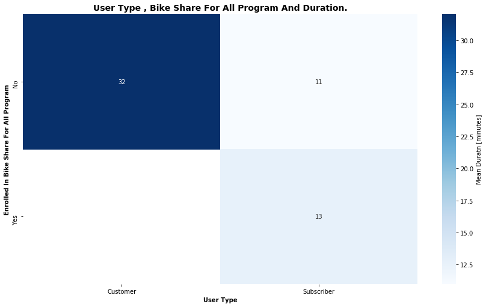

```python
plt.figure(figsize=(14.70,8.27))
#getting the grouped means with respect to both bike_share_for_all_trip and user_type and then resetting the index
group_mean = df.groupby(['bike_share_for_all_trip', 'user_type']).duration_minutes.mean()
group_mean = group_mean.reset_index()
#reshape the group_mean to use it in heatmap plot
group_mean = group_mean.pivot(index = 'bike_share_for_all_trip', columns = 'user_type',
                            values = 'duration_minutes')
#plotting a heat map and use annotations.
sns.heatmap(group_mean, annot = True,cmap='Blues',cbar_kws={'label': 'Mean Duratn [minutes]'})
plt.xlabel('User Type'.title(),
               fontsize = 10, weight = "bold")
plt.ylabel('Enrolled in Bike Share For All program'.title(),
               fontsize = 10, weight = "bold")
plt.title('User type , Bike Share For All program and Duration.'.title(),
               fontsize = 14, weight = "bold");
```

## Additional Geographic Visualisation.

The plot bellow showing the distribution of the bike stations all around San Francisco and it also showing the boundaries of San Francisco neighborhoods

- Here we can see that some neighborhood have no bike stations and others have few .
- Some stations are in quite small proximity .

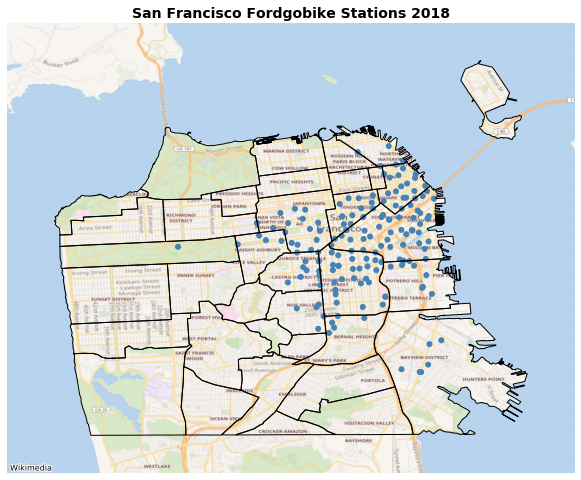

```python
#getting a  geoseries of the stations names that are located in San Francisco and thier coordinates.
bike_stations=geopandas.GeoSeries(df[df.sf_start].groupby('start_station_name').start_station_coor.unique().explode())
fig,ax=plt.subplots(1,figsize=(14.70,8.27))
geoplot.pointplot(bike_stations,ax=ax) # point plot of the stations
geoplot.polyplot(san_francisco,ax=ax,zorder=1) # plot of the neighborhoods boundaries
ctx.add_basemap(ax=ax,crs=san_francisco.crs,url=ctx.providers.Wikimedia); # plot of the of the base map .
plt.title('San Francisco Fordgobike stations 2018'.title(),
               fontsize = 14, weight = "bold");
```